# R Markdown, Knitr Assignment

##### 1.Loading and preprocessing the data

```r
MyData <- read.csv(file="activity.csv", header=TRUE, sep=",")
MyData_New <- subset(MyData, is.na(MyData$steps) == FALSE)
```

##### 2.Mean total number of steps taken per day

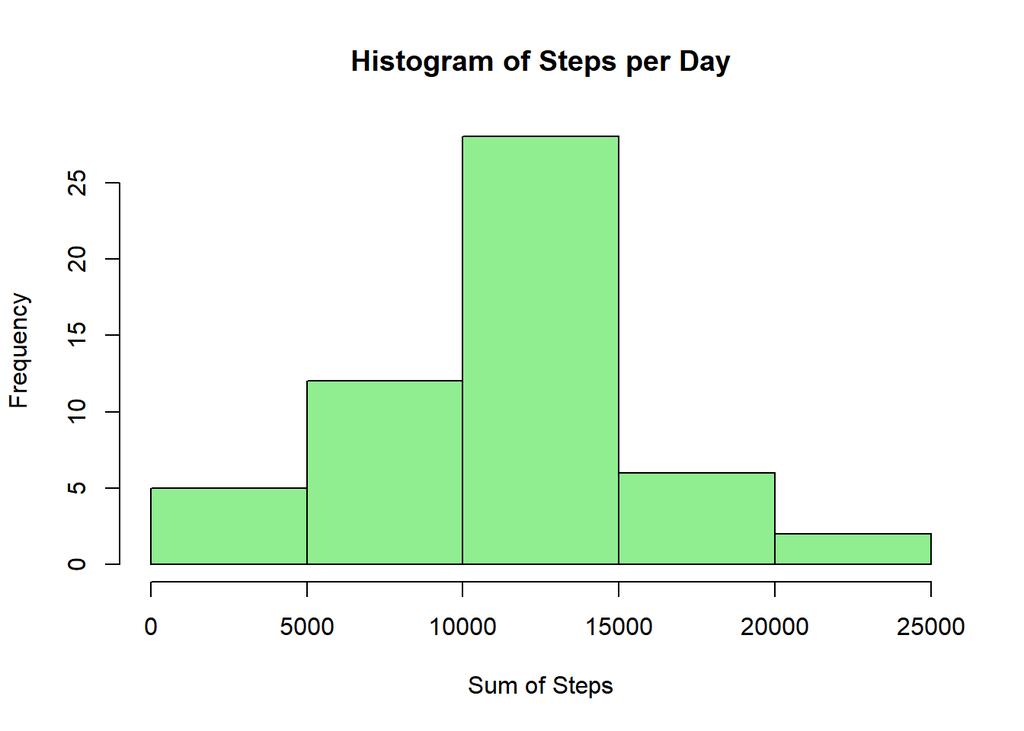

```r
require(stats)
MyData_Daysum <-tapply(MyData_New$steps, MyData_New$date, sum)
hist(MyData_Daysum, col="lightgreen", xlab ="Sum of Steps", main = "Histogram of Steps per Day")
```

```r
MyData_Daymean <-tapply(MyData_New$steps, MyData_New$date, mean, na.rm = TRUE)
MyData_Daymed <-tapply(MyData_New$steps, MyData_New$date, median , na.rm = TRUE)
```

###### The mean steps per day: NA, 0.4375, 39.4166667, 42.0694444, 46.1597222, 53.5416667, 38.2465278, NA, 44.4826389, 34.375, 35.7777778, 60.3541667, 43.1458333, 52.4236111, 35.2048611, 52.375, 46.7083333, 34.9166667, 41.0729167, 36.09375, 30.6284722, 46.7361111, 30.9652778, 29.0104167, 8.6527778, 23.5347222, 35.1354167, 39.7847222, 17.4236111, 34.09375, 53.5208333, NA, 36.8055556, 36.7048611, NA, 36.2465278, 28.9375, 44.7326389, 11.1770833, NA, NA, 43.7777778, 37.3784722, 25.4722222, NA, 0.1423611, 18.8923611, 49.7881944, 52.4652778, 30.6979167, 15.5277778, 44.3993056, 70.9270833, 73.5902778, 50.2708333, 41.0902778, 38.7569444, 47.3819444, 35.3576389, 24.46875, NA

###### The median steps per day: NA, 0, 0, 0, 0, 0, 0, NA, 0, 0, 0, 0, 0, 0, 0, 0, 0, 0, 0, 0, 0, 0, 0, 0, 0, 0, 0, 0, 0, 0, 0, NA, 0, 0, NA, 0, 0, 0, 0, NA, NA, 0, 0, 0, NA, 0, 0, 0, 0, 0, 0, 0, 0, 0, 0, 0, 0, 0, 0, 0, NA

##### 3. Average daily activity pattern

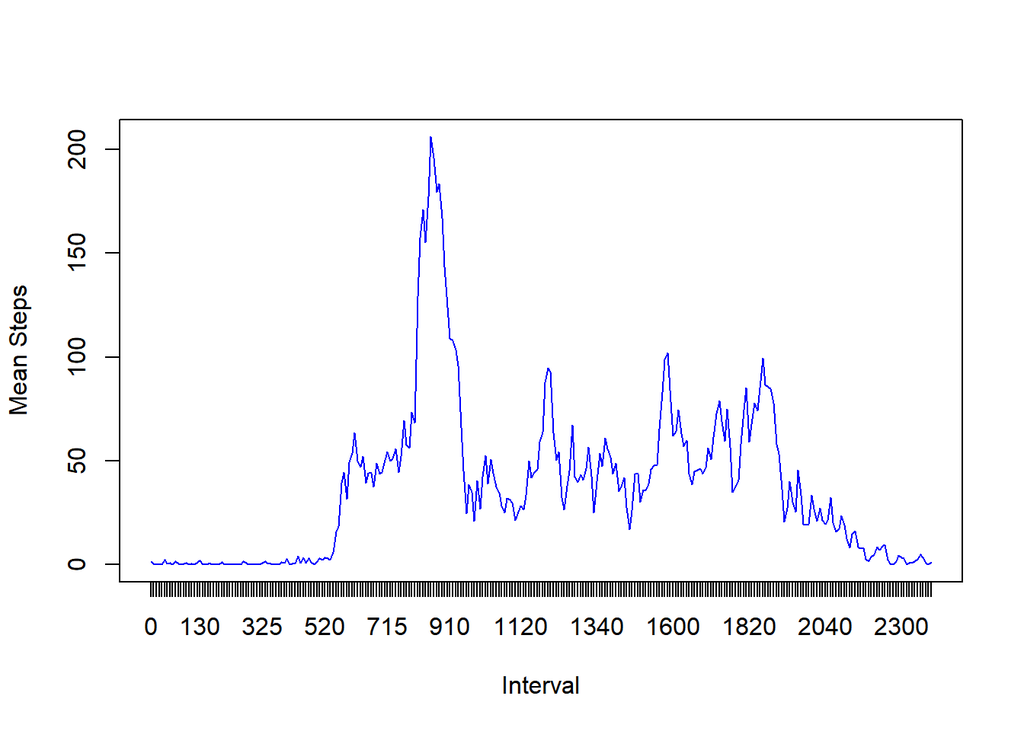

```r
MyData_Intrvmean <-tapply(MyData_New$steps, MyData_New$interval, mean)
plot(MyData_Intrvmean, type = "l",xlab ="Interval",ylab ="Mean Steps" ,xaxt = "n", col="blue" )
axis(1, at=1:length(names(MyData_Intrvmean)), labels =names(MyData_Intrvmean) )
```

```r
#Maximum average interval mean
MyData_Intrvmean_DF<- data.frame(interval=names(MyData_Intrvmean), value=MyData_Intrvmean)
x <-MyData_Intrvmean_DF[which.max(MyData_Intrvmean_DF$value),]
```

###### The maximum of average steps per day 206.1698113 falls at 835th interval

##### 4. Imputing missing values

###### Count of missing values 2304 using nrow(MyData[!complete.cases(MyData),])

```r
MyData2 <- MyData
cleanBase2 <- MyData2[!is.na(MyData2$steps),]
missingData <- is.na(MyData2$steps)
meanVals <- tapply(cleanBase2$steps, cleanBase2$interval, mean, na.rm=TRUE, simplify=TRUE)
MyData2$steps[missingData] <- meanVals[as.character(MyData2$interval[missingData])]
#count of missing values in new data
nrow(MyData2[!complete.cases(MyData2),])
```

```
## [1] 0
```

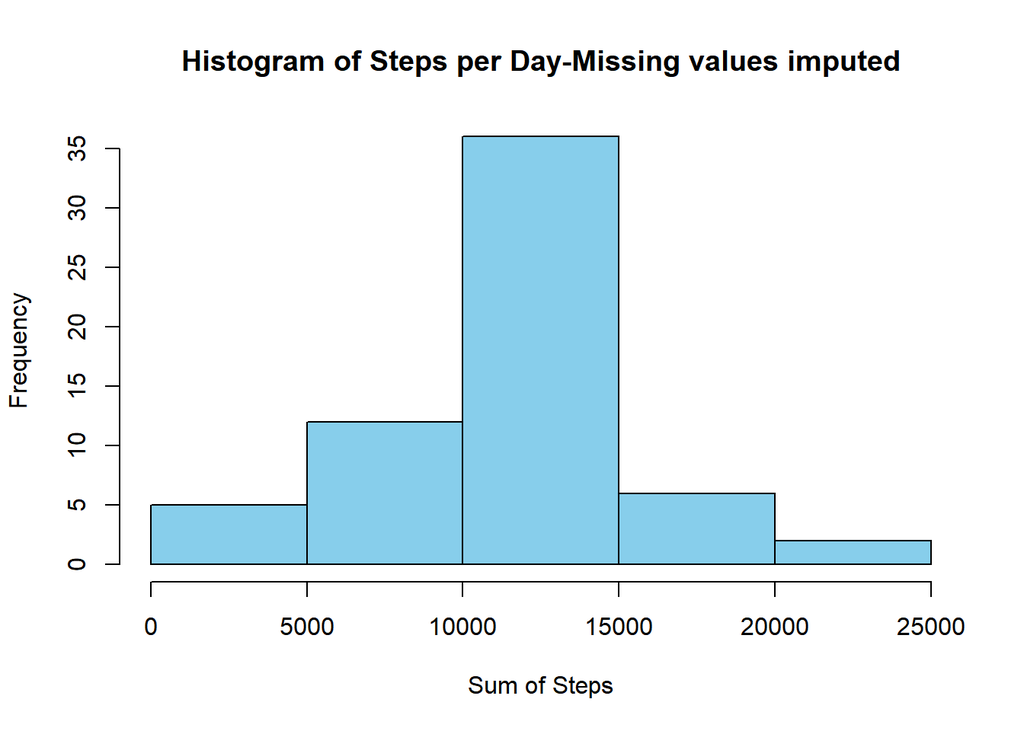

```r
#imputed histogram
MyData2_Daysum <-tapply(MyData2$steps, MyData2$date, sum)
hist(MyData2_Daysum, col="skyblue", xlab ="Sum of Steps", main = "Histogram of Steps per Day-Missing values imputed")
```

```r
MyData2_Daymean <-tapply(MyData2$steps, MyData2$date, mean)
MyData2_Daymed <-tapply(MyData2$steps, MyData2$date, median)

#Calculate and report the mean and median total number of steps taken per day.
MyData_Daysum_DF<- data.frame(day=names(MyData_Daysum), value=MyData_Daysum)
MyData2_Daysum_DF<- data.frame(day=names(MyData2_Daysum), value=MyData2_Daysum)

D <-median(MyData_Daysum_DF$value, na.rm =  TRUE)
D2 <-median(MyData2_Daysum_DF$value, na.rm =  TRUE)
S <- round((sum(MyData_Daysum_DF$value, na.rm =  TRUE))/61,2)
S2 <-round((sum(MyData2_Daysum_DF$value, na.rm =  TRUE))/61,2)
```

[output not shown]

##### Are there differences in activity patterns between weekdays and weekends?

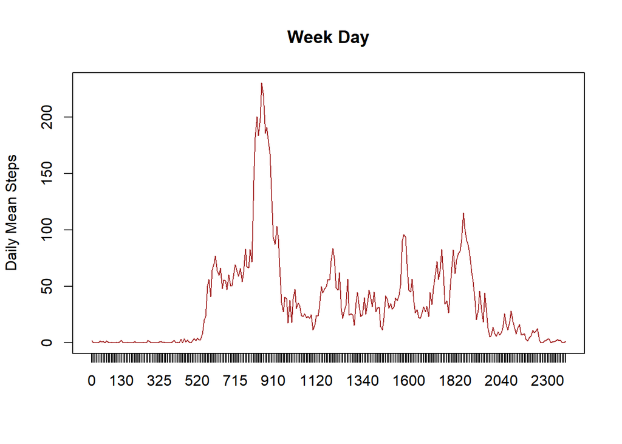

```r
MyData2_Wk <- MyData2
MyData2_Wk$WkDay_WkEnd <-ifelse( weekdays(as.Date(MyData2_Wk$date)) == "Saturday" | weekdays(as.Date(MyData2_Wk$date)) == "Sunday", "WkEnd", "WkDay")
MyData2_WkDay <- MyData2_Wk[MyData2_Wk$WkDay_WkEnd == "WkDay", ]
MyData2_WkEnd <- MyData2_Wk[MyData2_Wk$WkDay_WkEnd == "WkEnd", ]
MyData2_WkDay <- tapply(MyData2_WkDay$steps, MyData2_WkDay$interval, mean, na.rm = TRUE)
MyData2_WkEnd <- tapply(MyData2_WkEnd$steps, MyData2_WkEnd$interval, mean, na.rm = TRUE)
##Plots of Weekday, Weekend
plot(MyData2_WkDay, type = "l",main ="Week Day",xlab="",ylab ="Daily Mean Steps" ,xaxt = "n", col="brown" )
axis(1, at=1:length(names(MyData2_WkDay)), labels =names(MyData2_WkDay) )
```

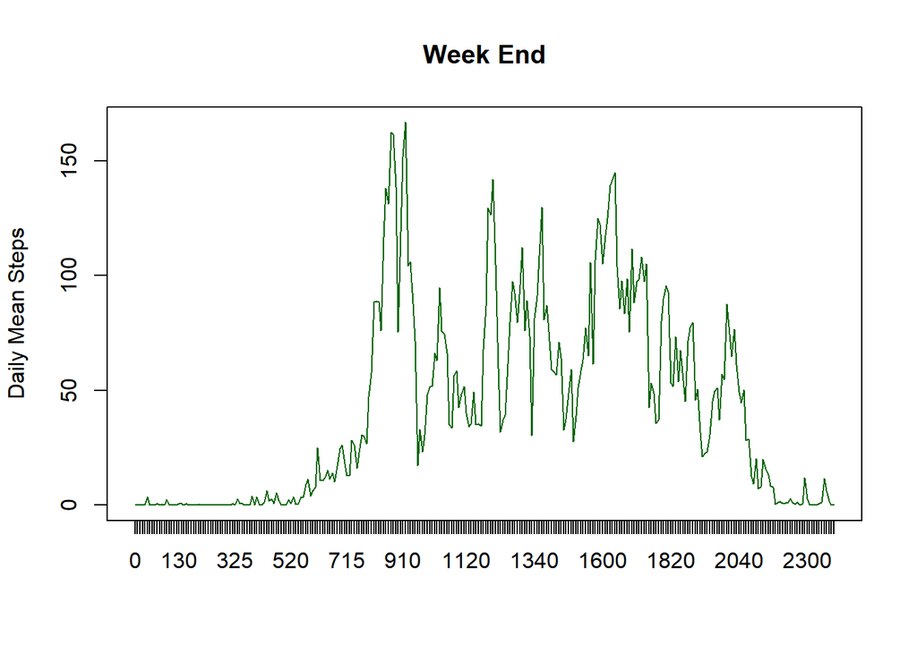

```r
plot(MyData2_WkEnd, type = "l",main ="Week End",xlab="",ylab ="Daily Mean Steps" ,xaxt = "n", col="darkgreen" )
axis(1, at=1:length(names(MyData2_WkEnd)), labels =names(MyData2_WkEnd) )
```